# Spatial Coupled HMM Update

## Coupled HMM

Let $G$ reflect the number of states, $N$ the number of spatial locations and $T$ be the length of each time series (assumed to be equal).

For now, we suppose that the observation process is conditionally independent given the state process, as such:

$$[ Y_t^{[n]} | Z_t^{[n]} ] \sim N(\mu_g^{[n]}, \sigma_g^{[n]})$$

And the transition probability matrix is the same at all locations, with entries:

$$mlogit(\gamma_{ij}^{[n]}) = \beta_{0, ij}^{[n]} + \beta \sum_{s \sim n}\text{I}\left(Z_{t-1}^{[s]} = j\right)$$

## MCMC

We use a Gibbs sampler to obtain draws from the joint posterior distribution, as detailed in `Scalable Bayesian Inference for Coupled Hidden Markov and Semi-Markov Models` (Touloupou et al, 2019).

That is, we alternate between drawing from the distribution of $Pr(\boldsymbol{Z}^{[n]} | \boldsymbol{Y}^{[n]}, \boldsymbol{Z}^{[-n]})$ using the individual Forward Filtering Backward Sampling algorithm and using other approaches to draw from the joint distribution of the state-dependent parameters and parameters of the t.p.m.

For $p(\boldsymbol{\mu}, \boldsymbol{\sigma}| \cdot )$ we use conjugate priors and sample directly from the conditional posterior distribution.

For $p(\boldsymbol{\beta}| \cdot)$ we use Hamiltonian Monte Carlo.

## Augspurger Data

For a single site, Augspurger, modeling a week of data as a Markov-switching AR(1) process. First, we can visualize the Augspurger data set at the original 5-minute interval from approximately Jan 1-8, 2015.

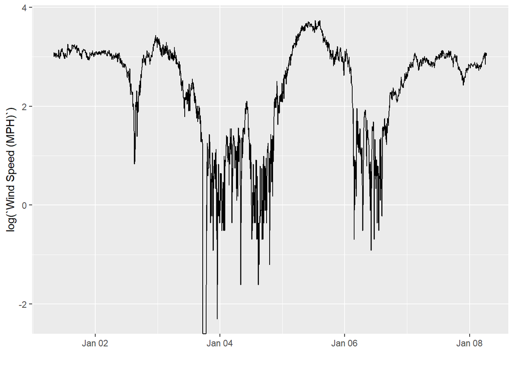

The model is extended in order to account for conditional dependence among the observations, rather than the general conditional independence assumed by an HMM.

State-dependent distributions:

$$[ Y_t|Z_t = g ] \sim N\left( \mu_g + \rho_g (Y_{t-1} - \mu_g), \sigma_g \right)$$
For now, we assume a time-homogeneous Markov process for the states.

### 2-state MS-AR(1) Results

Marginal distributions of $\mu_g$:

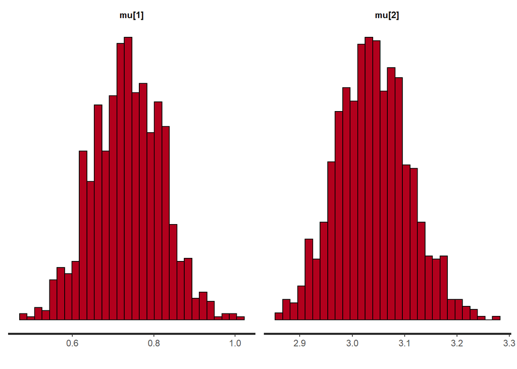

Marginal distributions of $\rho_g$:

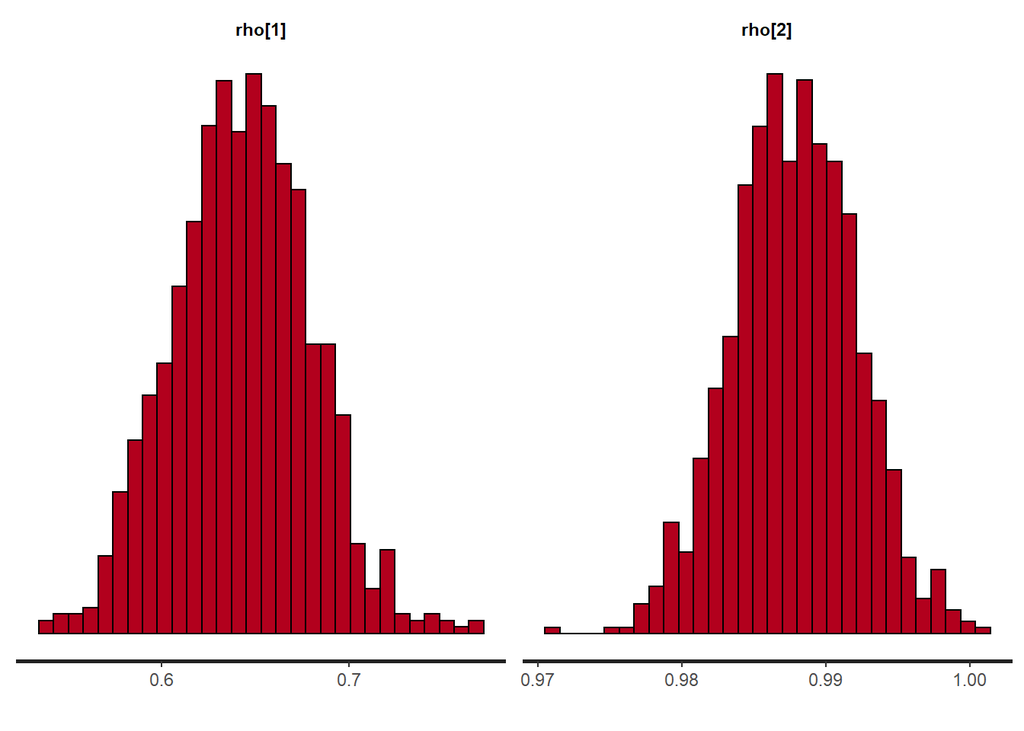

Marginal distribution of the transition probability matrix (TPM):

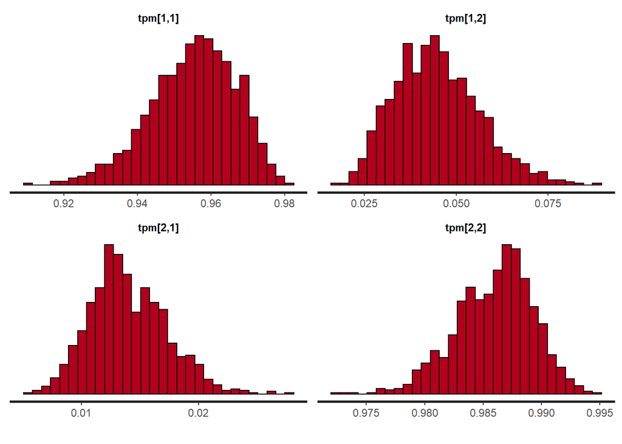

### 3-state MS-AR(1) Results

The specification of the 3 states results in a mismatch between the model specification and the data, leading to multiple local modes in the posterior distribution.

Marginal distributions of $\mu_g$:

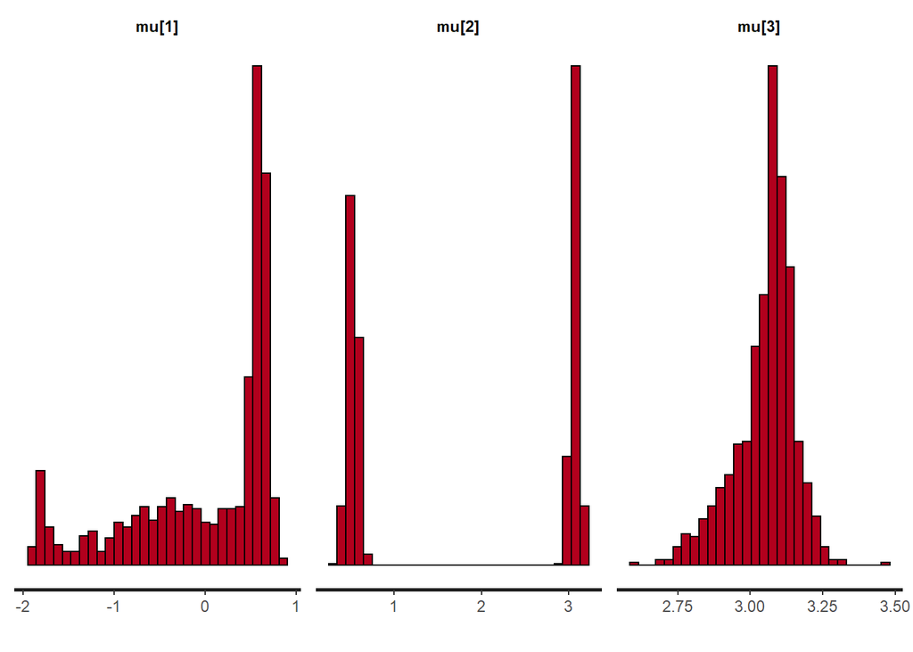

Marginal distributions of $\rho_g$:

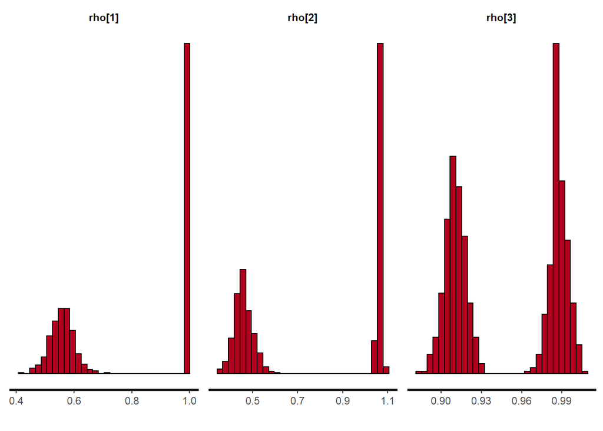

Of note for the marginal distributions of the $\rho_g$ are the times when $\rho_g \approx 1$.

Marginal distribution of the transition probability matrix (TPM):

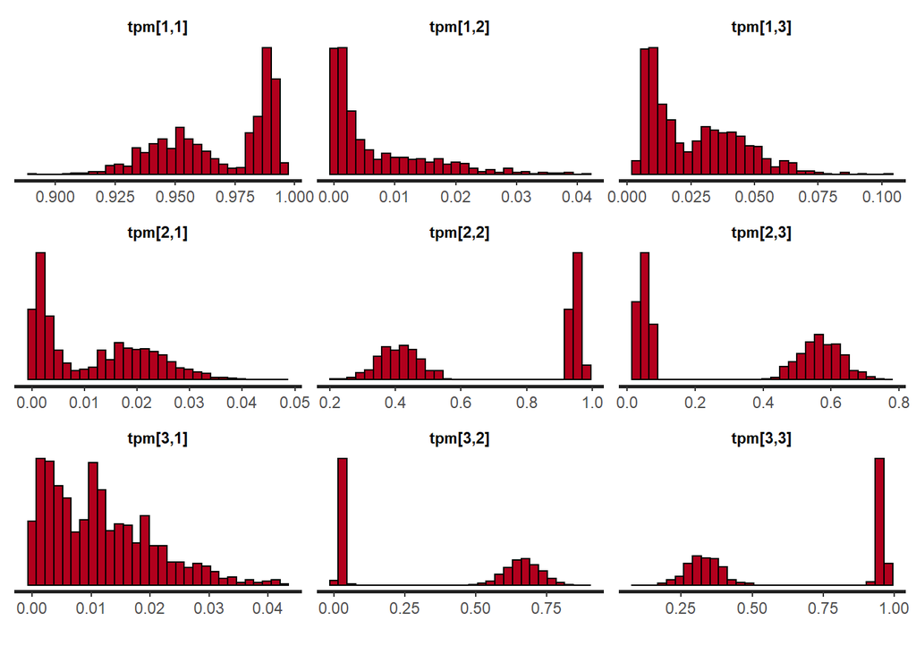

## Next Steps

Model construction and MCMC is starting from a simpler construction, while analysis of the actual data is beginning with MS-AR modeling frameworks for each individual location.

1. Fit MS-AR models to each location with the same number of states
2. Finish the MCMC for the coupled HMM for multiple locations
3. Extend the coupled HMM MCMC to account for the autoregressive processes